# NFL Punt Directional Analysis

This report examines the distribution of punt angles using the provided Next Gen Stats tracking data. The data loaded below is created from another submitted kernel by Kostas.

```r
# Load the data made by Kostas' kernel:
load("angles.RDa")
# Access tidyverse:
# install.packages("tidyverse")
library(tidyverse)
# Using the dataset created by Kostas from the Next Gen Stats files, first
# create new fields that are normalizing the location and directions of
# punts on the cartesian plane. This means flipping the x and y values for
# punts that took place on the right side of the field since they were going
# other way:
punt_data <- loc.punt.RetFC %>%
  # First flip the x coordinates based on whether or not the punter was on the
  # right half of the field (in terms of the endzones, not sidelines)
  mutate(x1_flip = ifelse(x1 > 60, 120 - x1, x1),
         x2_flip = ifelse(x1 > 60, 120 - x2, x2),
         # Flip the y coordinates based on whether or not the punter was on the
         # right half of the field (in terms of endzones), and flip the y-coordinates
         # so all punts are with respect to the sideline they are closest to.
         # This means the visitor sideline should be on the left (with respect to
         # the punter) for punts on the
         # left side of the field (with respect to endzone), but are on the right
         # (with respect to the punter) on the right side of the field:
         y1_flip = ifelse(x1 > 60, max(loc.punt.RetFC$y2) - y1, y1),
         y2_flip = ifelse(x1 > 60, max(loc.punt.RetFC$y2) - y2, y2),
         # Get the x with respect to the line of scrimmage
         x1_los = yrdline + 10,
         # Now place line of scrimmage and vertical location of the punt at
         # cartesian origin:
         x1_shift = 0,
         x2_shift = x2_flip - x1_los,
         y1_shift = 0,
         y2_shift = y2_flip - y1_flip) %>%
  # Use the useful package to get the polar coordinates for the punts with
  # respect to the closest sideline:
  bind_cols(dplyr::select(useful::cart2pol(.$x2_shift, .$y2_shift, degrees = FALSE),
                          r, theta) %>%
              rename(ref_theta = theta),
            dplyr::select(useful::cart2pol(.$x2_shift, .$y2_shift, degrees = TRUE),
                                           theta) %>%
              rename(ref_angle = theta)) %>%
  # Allow the angles to be negative on the right hand side:
  mutate(mirror_angle = ifelse(ref_angle > 180, ref_angle - 360, ref_angle))
```

Using this adjusted data, we can create a plot displaying the mean distance in yards from the line of scrimmage to where the ball landed by direction:

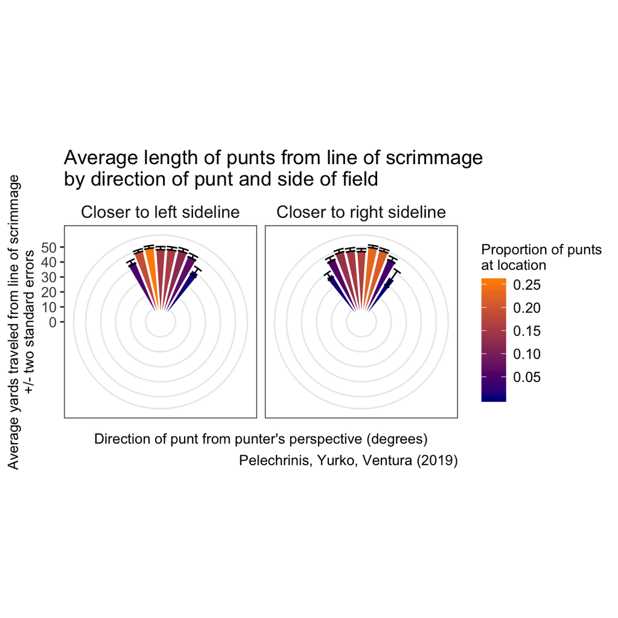

```r
punt_data %>%
  # Create a field denoting which sideline left or right the punter
  # was closer to:
  mutate(field_bucket_x = cut(x1_los, breaks = c(0, 10, 20, max(x1_los)),
                              labels = c("0 - 10 yardline",
                                         "11 - 20 yardline",
                                         "21+ yardline")),
         field_bucket_x = fct_rev(field_bucket_x),
         field_bucket_y = cut(y1_flip, breaks = c(0, max(loc.punt.RetFC$y2) / 2,
                                                  max(loc.punt.RetFC$y2)),
                              labels = c("Closer to right sideline",
                                         "Closer to left sideline")),
         field_bucket_y = fct_rev(field_bucket_y),
         angle_bucket = cut(mirror_angle, breaks = seq(-180, 180, by = 360/41))) %>%
  unite(punt_group, "field_bucket_x", "field_bucket_y", "angle_bucket",
        remove = FALSE) %>%
  group_by(field_bucket_y) %>%
  mutate(n_punts_location = n()) %>%
  ungroup() %>%
  group_by(field_bucket_y, angle_bucket) %>%
  summarise(prop_punts = n() / first(n_punts_location),
            mean_length = mean(x2_shift),
            se_length = sd(x2_shift) / sqrt(n())) %>%
  ggplot(aes(x = angle_bucket,
             y = mean_length, fill = prop_punts)) +
  geom_bar(stat = "identity", color = "white") +
  geom_errorbar(aes(ymin = mean_length - 2 * se_length,
                    ymax = mean_length + 2* se_length),
                color = "black") +
  scale_x_discrete(drop = FALSE, breaks = "") +
  scale_fill_gradient(low = "darkblue", high = "darkorange") +
  coord_polar(direction = -1, start = pi) +
  theme_bw() +
  labs(x = "Direction of punt from punter's perspective (degrees)",
       y = "Average yards traveled from line of scrimmage\n+/- two standard errors",
       title = "Average length of punts from line of scrimmage\nby direction of punt and side of field",
       caption = "Pelechrinis, Yurko, Ventura (2019)",
       fill = "Proportion of punts\nat location") +
  facet_wrap(~field_bucket_y, ncol = 2) +
    theme(axis.title = element_text(size = 10),
        axis.text = element_text(size = 10),
        plot.title = element_text(size = 14),
        plot.subtitle = element_text(size = 10),
        plot.caption = element_text(size = 10),
        strip.background = element_blank(),
        strip.text = element_text(size = 12),
        legend.text = element_text(size = 10),
        legend.title = element_text(size = 10))
```

We also explored modeling the punts using a mixture of von Mises-Fisher distributions. The goal was to see if there are clusters of punts based solely on the direction:

```r
# Access the movMF package
# install.packages("movMF")
library(movMF)
# Fit various mixtures of von Mises-Fisher distributions from 1 to 10 clusters,
# with varying concentration parameter estimates for the clusters:
punt_movmfs <- map(1:10,
                   function(g) {
                     movMF(as.matrix(dplyr::select(punt_data, x2_shift, y2_shift)),
                           k = g, nruns = 20)
                              })
# Calculate the BIC for each
vary_kappa_bic <- sapply(punt_movmfs, BIC)
names(vary_kappa_bic) <- paste0("Varying kappa: ", c(1:10))
# Repeat but for mixtures with common concentration:
punt_movmfs_common <- map(1:10,
                   function(g) {
                     movMF(as.matrix(dplyr::select(punt_data, x2_shift, y2_shift)),
                           k = g, nruns = 20, kappa = list(common = TRUE))
                              })
common_kappa_bic <- sapply(punt_movmfs_common, BIC)
names(common_kappa_bic) <- paste0("Common kappa: ", c(1:10))
# Which was the minimum:
names(c(vary_kappa_bic, common_kappa_bic))[which.min(c(vary_kappa_bic, common_kappa_bic))]
```

```
[1] "Common kappa: 2"
```

```r
# Select G = 2 with common kappa (concentration parameter - basically inverse of variance)
```

This means the optimal mixture, according to BIC (for better or worse…) is two distributions with equal concentration parameter estimates (think of the concentration as the inverse of the variance, as the concentration goes to infinity you simply have a point mass).

We can use the mixture parameter estimates to then give us the estimated mean direction for both of these clusters:

```r
punt_movmfs_common[[2]]$theta %>%
  as.data.frame() %>%
  bind_cols(useful::cart2pol(.$x2_shift, .$y2_shift, degrees = TRUE)) %>%
  rename(mean_direction = theta) %>%
  mutate(mean_direction = ifelse(mean_direction > 180, mean_direction - 360,
                                 mean_direction)) %>%
  dplyr::select(mean_direction) %>%
  mutate(cluster = c(1, 2))
```

```
  mean_direction cluster
1       11.79318       1
2      -11.92129       2
```

The two clusters we identified are simply the punts to which ever sideline they are closer to. This means if we calculate the punt directions relative to the closest sideline then we would not see a clear mixture or obvious group structure of different punt directions.

The figure below captures the cluster differences just based on which side of the field the punt landed.

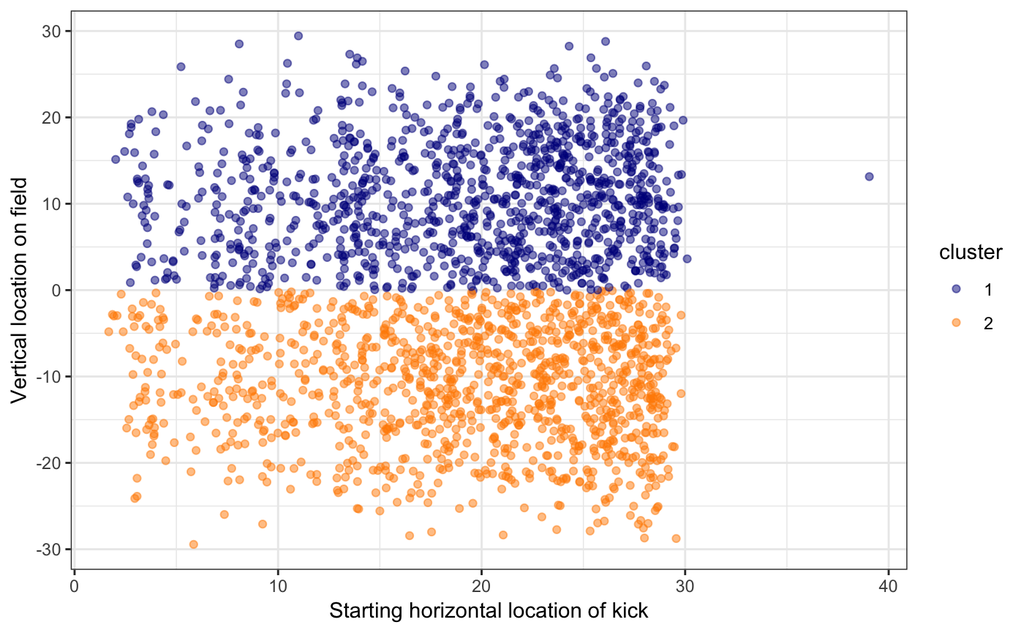

```r
punt_data %>%
  mutate(cluster = as.factor(predict(punt_movmfs_common[[2]]))) %>%
  ggplot(aes(x = x1_flip, y = y2_shift, color = cluster)) +
  scale_color_manual(values = c("darkblue", "darkorange")) +
  geom_point(alpha = 0.5) +
  theme_bw() +
  labs(x = "Starting horizontal location of kick",
       y = "Vertical location on field")
```